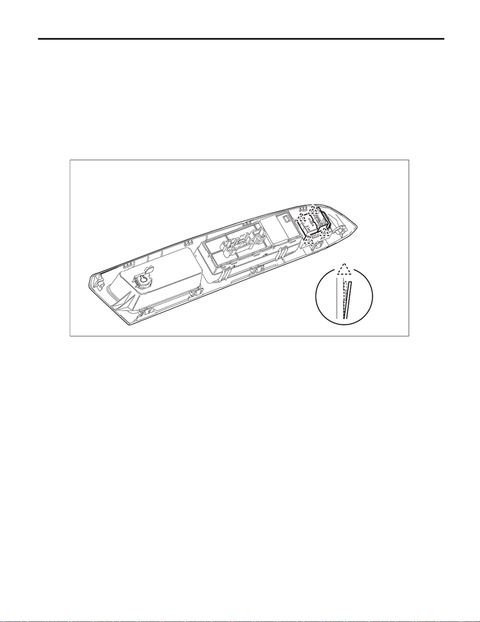

GW-31

Remote Control Mirror Switch

GLASS/WINDOWS/MIRRORS

9. Remote Control Mirror Switch

A: REMOVAL

1) Disconnect the ground cable from battery and wait for at least 60 seconds before starting work. <Ref. to

NT-5, BATTERY, NOTE, Note.>

NOTE:

For models other than STI model, disconnect the ground terminal from battery sensor.

2) Remove the trim panel - front door. <Ref. to EI-56, FRONT DOOR, REMOVAL, Door Trim.>

3) Remove the panel - power window main switch. <Ref. to GW-11, REMOVAL, Power Window Control

Switch.>

4) Release the claws, and then remove the switch - door mirror from the panel - power window main switch.

B: INSTALLATION

1) Install the switch - door mirror to the panel - power window main switch.

2) Install the panel - power window main switch to the trim panel - front door.

3) Install the trim panel - front door.

4) Connect the battery ground terminal. <Ref. to NT-5, BATTERY, NOTE, Note.>

NOTE:

For models other than STI model, connect the ground terminal to battery sensor.

GW-01416

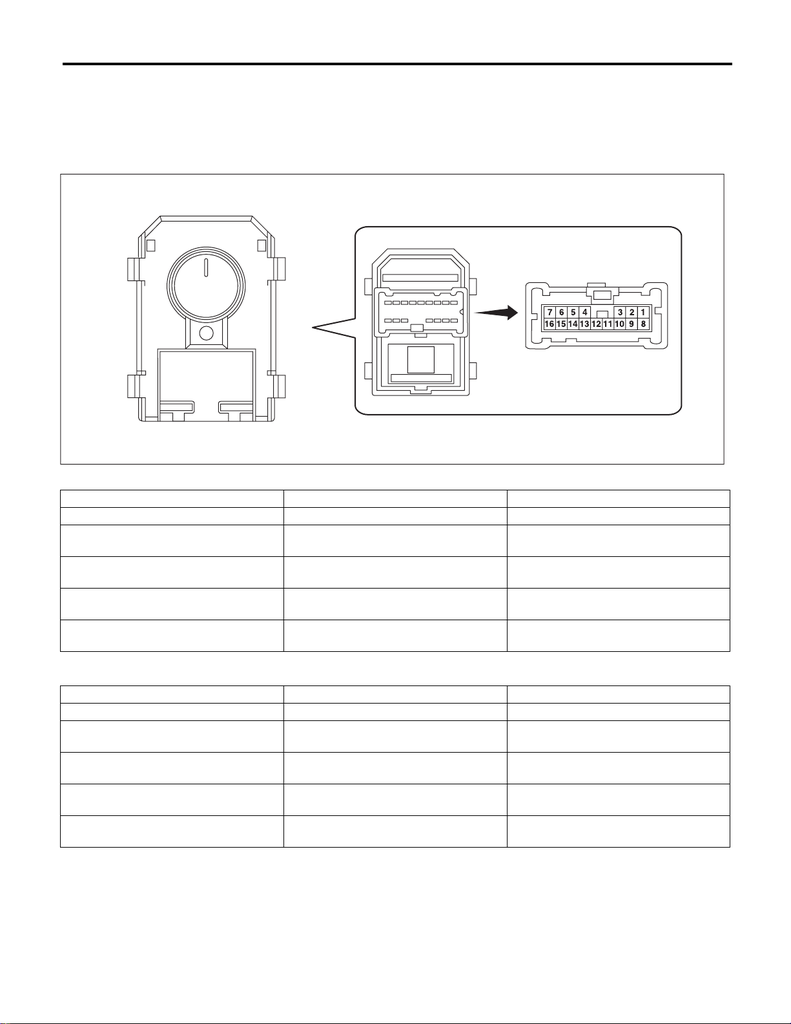

GW-32

Remote Control Mirror Switch

GLASS/WINDOWS/MIRRORS

C: INSPECTION

1) Disconnect the connector of the switch - door mirror.

2) Check the resistance between switch - door mirror terminals.

Preparation tool:

Circuit tester

• Changeover switch RH

• Changeover switch LH

3) If the inspection result is not within the standard, replace the switch - door mirror.

Terminal No. Inspection conditions Standard

— OFF 1 MΩ or more

1 — 12

9 — 7

UP Less than 1 Ω

1 — 9

12 — 7

DOWN Less than 1 Ω

1 — 11

12 — 7

LEFT Less than 1 Ω

1 — 12

11 — 7

RIGHT Less than 1 Ω

Terminal No. Inspection conditions Standard

— OFF 1 MΩ or more

1 — 14

8 — 7

UP Less than 1 Ω

1 — 8

14 — 7

DOWN Less than 1 Ω

1 — 10

14 — 7

LEFT Less than 1 Ω

1 — 14

10 — 7

RIGHT Less than 1 Ω

GW-01174